# hw3

**Q1**

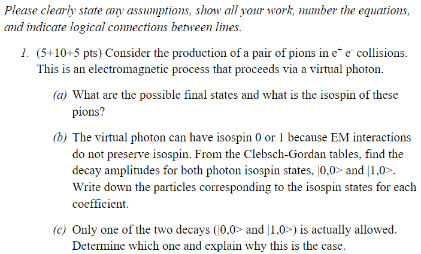

(a) Possible outcomes with net zero charge:

$$ \pi^0 \pi^0 \\ \pi^+ \pi^- $$ From the quark contents of these pions (1/2 isospin), we have these $$ \pi^0:\ |1,0 \rangle \\ \pi^+:\ |1,1 \rangle \\ \pi^-:\ |1,-1 \rangle $$

(b) Decay amplitudes

The photon has isospin $|J,M\rangle$ which correspond to the top bar. We use the 1x1 table since each pion $l=1$.

We can find the probability of decaying to $m_1,m_2$ using the table

For photon isospin $|1,0\rangle$:

$$ \begin{matrix} \text{state} & m_1, m_2 & \text{amplitude} \\ |\pi^+ \pi^- \rangle & +1, -1 & \sqrt{1/2} \\ |\pi^0 \pi^0\rangle & 0, 0 & 0 \\ |\pi^- \pi^+ \rangle & -1, +1 & \sqrt{1/2} \\ \end{matrix} $$

For photon isospin $|0, 0 \rangle$:

$$ \begin{matrix} \text{state} & m_1, m_2 & \text{amplitude} \\ |\pi^+ \pi^- \rangle & +1, -1 & \sqrt{1/3} \\ |\pi^0 \pi^0\rangle & 0, 0 & -\sqrt{1/3}\\ |\pi^- \pi^+ \rangle & -1, +1 & \sqrt{1/3} \\ \end{matrix} $$

(c) Can photons decay into $\pi^0 \pi^0$ in nature? Both $\pi^0\pi^0$ and $\pi^+ \pi^-$ are eigenstates of $C$, only with different eigenvalues.

Since only $\pi^+ \pi^-$ has the same eigenvalue as $C\gamma = -1 \gamma$, $\gamma$ cannot pair-produce $\pi^0\pi^0$ and only isospin $|1,0\rangle$ is valid

**Q2**

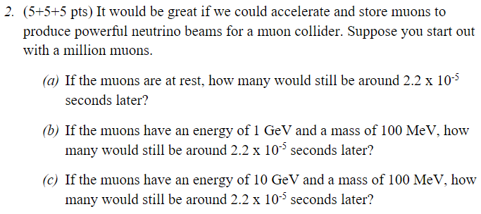

(a) $N(t) = N_0 e^{-t/\tau}$

Muon half life: 1.56 $\mu s = 1.56\times 10^{-6}s$. That means 14 half-lives will pass. Only 56 muons will remain.

(b) $E = \gamma m \rightarrow \gamma = E/m = 10$

One second for the particle is ten seconds for us.

$$ \Delta t' = \gamma \Delta t \\ 2.2\times 10^{-5} / 10 = 2.2\times 10^{-6} \\ $$ Now this is 1.4 half-lives. 376k muons remain

(c) $\gamma = 100$. 91% or 907k of the muons remain

**Q3**

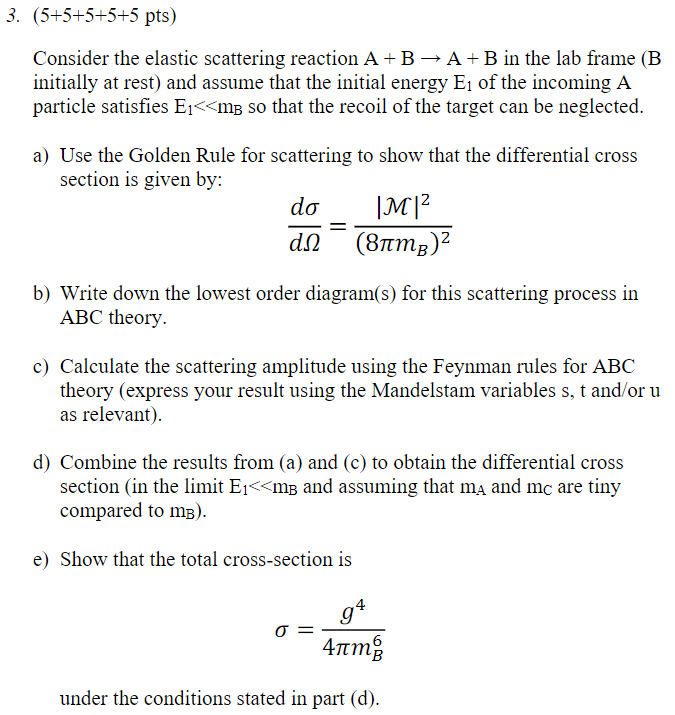

(a) Griffiths does most of the heavy lifting in 6.2.2

Since $m_b$ is very large, the lab frame and CM frame are the same and we can use the formula from Griffiths

$$ \frac{d\sigma}{d\Omega} = \left(\frac{\hbar c}{8 \pi} \right)^2 \frac{S |\mathcal M|^2}{(E_1 + E_2)^2} \frac{|p_f|}{|p_i|} $$ Elastic scattering conserves momentum $|p_f| = |p_i|$, $S=1$, and the condition $E_2 = m_b$ and $m_b \gg E_1$ means $(E_1 + E_2)^2 = (E_1 + m_b)^2 \approx m_b^2$

These conditions give us our result ($c=\hbar = 1$)

$$ \frac{d\sigma}{d\Omega} = \left(\frac{1}{8 \pi} \right)^2 \frac{ |\mathcal M|^2}{(m_b)^2} \frac{|p_i|}{|p_i|} = \frac{|\mathcal M|^2}{(8 \pi m_b )^2} $$

Note: Why are lab frame and CM frame the same? We often use $\sum \vec p_i = 0$ for CM frame, but it is equivalent to say the center of mass doesn't move. The fact that B doesn't recoil after collision with A indicates the center of mass isn't really changing

(b)

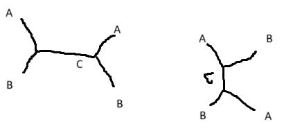

Since the particles in and out are distinguishable, we don't have to worry about a u-channel. Momentum can be defined by particle in -and particle out- momenta

(c)  
$\mathcal M = i (\text{vertex factors})(\text{propogator factors})(\text{momentum conservation})$

We'll use $p_{Ai},\ p_{Bi}$ for incoming particles and $p_{Af}, p_{Bf}$ for outgoing. Remember the extra $2\pi$ factors, only one set is removed after integration

1st diagram: $$ \mathcal M_1 = i \int \frac{d^4 p_c}{2\pi^4} \\ \times (-ig)(-ig) \left(\frac{i}{p_C^2 - m_C^2}\right)(2\pi \delta(p_{Ai} + p_{Bi} - p_{C}))^4 (2\pi \delta(p_{C} - p_{Af} - p_{Bf}))^4 \\ p_C \rightarrow p_{Ai} + p_{Bi} \\ \mathcal M_1 = \frac{(2 \pi) ^4 g^2}{\left(p_{Ai} + p_{Bi} \right)^2 - m_C^2} \delta^4(p_{Ai} + p_{Bi} - p_{Af} - p_{Bf}) \\ = \frac{g^2}{s - m_C^2} $$

Rereading the lecture slides, it looks like we drop the extra $(2\pi)^2\delta^4$ term.

The second diagram is similar, only with momentum swapped around. The delta functions are now

$$ \delta^4(p_{Ai} + p_{C} - p_{Bf}) \\ \delta^4(p_{B_i}- p_{C} - p_{Af}) \\ p_C \rightarrow p_{Bf} - p_{Ai} \\ \rightarrow \delta^4(p_{B_i}+ p_{A_i} - p_{Bf} - p_{Af}) \\ $$ Note that the only change is in the propogator factor

$$ \mathcal M_2 = \frac{g^2}{t - m_C^2} $$

(d) $m_a$ and $m_c$ small imply that $m_b$ dominates in the squared terms. In (e) we'll need more factors of $1/m_B$. Remember that squaring a 4-vector returns it's total energy.

$$ s = p_{Ai}^2 + p_{Bi}^2 + 2p_{Ai} \cdot p_{Bi} = E_A^2 + E_B^2 + 2E_A E_B \\ s \sim 0^2 + m_B^2 + 2(0)(m_B) = m_B^2 \\ t = p_{Bf}^2 + p_{Ai}^2 - 2E_A E_B \sim m_B^2 $$ These terms both collapse down to approximately $m_B^2$ under the right conditions $$ |\mathcal{M}_{\text{tot}}|^2 = \frac{g^4}{(s - m_C^2)^2} + \frac{g^4}{(t - m_C^2)^2} + 2 \frac{g^4}{(s - m_C^2)(t - m_C^2)} \\ = 4\frac{g^4}{m_B^4} $$ The $m_B$ term 'eats' all the smaller masses when the denominators are squared. $s \times m_C^2$ and $t \times m_C^2$ both go to zero since $m_C$ is very small.

The final result for differential cross section thus is

$$ \frac{d\sigma}{d\Omega} = \frac{1}{(8 \pi m_B)^2} \frac{4 g^4}{m_B^4}\\ = \frac{g^4}{16 \pi^2 m_B^6} $$

(e) Our differential cross section doesn't rely on $\theta$ or $\phi$, so this is

$$ \int \frac{d \sigma}{d\Omega} d\Omega = 4\pi \frac{d\sigma}{d\Omega} = \frac{g^4}{4 \pi m_B^6} $$

This worked out pretty well after I remembered we were working with 4-vectors instead of 3-vectors

**Q4**

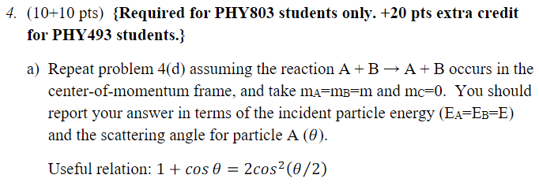

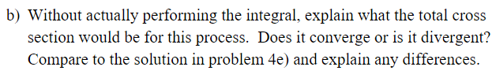

This result will be somewhat similar to our answer in the slides, I hope

(a)

$$ \frac{d \sigma}{d \Omega} = \frac{|\mathcal M|^2}{(16 \pi E)^2} \\ s = E^2 + E^2+ 2E^2 = 4E^2 \\ t = E^2 + E^2 - 2E^2 = 0??? $$

Wait, doest that mean $\mathcal M_2 \sim \frac{1}{0}?$ Not quite.

$p_{Bf} \cdot p_{Ai}$ depends on angles, since momentum can shift between A and B, even if total momentum is conserved $p_{Bi} \cdot p_{Ai} = E^2$

According to our slides, $t = -2p^2(1-\cos \theta) $

$$ t^2 = 4E^4 \left(\cos^2(\theta) -2\cos(\theta)+ 1 \right) \\ st = -8E^2(1-\cos(\theta)) $$

$$ |\mathcal{M}_{\text{tot}}|^2 = \frac{g^4}{s^2} + \frac{g^4}{t^2} + 2 \frac{g^4}{st} \\ = \frac{g^4}{16E^4} + \frac{g^4}{4p^2 (1-\cos \theta)^2} - \frac{g^4}{4E^2 p^2 (1-\cos \theta)} \\ = \frac{g^4 \left[ p^2(1-\cos \theta) - 2E^2 \right]^2}{16E^4 p^2(1-\cos(\theta))^2} $$ I'm a bit worried that we're not using the hint, and expanding this out won't necessarily simplify things.

$$ \frac{d\sigma}{d\Omega} = \frac{1}{(16 \pi E)^2} \left[\frac{g^4 \left[ p^2(1-\cos \theta) - 2E^2 \right]^2}{16E^4 p^2(1-\cos(\theta))^2} \right] $$

(b) It appears as though this value diverges, which is unfortunate since I didn't expect it to. The $1-cos(\theta)$ term seen multiple times in $\mathcal M$ results in infinite values at certain angles. Perhaps this means the particles cannot scatter when $\theta=0$, so the cross section explodes.

3e didn't have this issues since one particle was truely stationary.